# Nested Designs (cont.)

NRES 710

Last compiled: 2024-11-26

So last class we discussed nested designs, and specifically how they can handle pseudoreplication and random effects that are nested within each other.

Today I want to show you the upper limits of what this design can handle – and some constraints that emerge.

## Split-plot Design

Let’s consider a field experiment with six fields and four variables:

- $Y = biomass$
- $X_1 = bison (yes/no)$
- $X_2 = fertilizer (yes/no)$
- $X_3 = water (low/medium/high)$
- $X_4 = pesticide (yes/no)$

We want this to be a **fully-factorial design**, where we will cross every single one of these variables with every other variable.

- E.g., bison, no fertilizer, medium water, no pesticide
- E.g., no bison, fertilizer, high water, pesticide
- We will have a replicate for every combination of treatments in each field.
- 2 bison * 2 fertilizer * 3 water * 2 pesticides = 24 plots within each field.
- We need to break up each field into 24 blocks to do all of these combinations.

If we created a tiny block (1/24th of field) and put a bison into it, in two months when we come back to measure the effects, the bison will be dead and all the biomass will be gone.

So an alternative way to approach this would be to split each field in half. Each half will be randomly assigned to have a bison or not.

Now, we’ll take every ‘bison plot’, split those in half, and randomly assign fertilizer or no fertilizer treatment.

Now, we’ll take every fertilizer plot, split those in three, and randomly assign water: low, medium, high.

Last, we’ll take each water plot, split those in half, and randomly assign pesticide/no pesticide. This is what this would look like:

*Brian draw this on the board: field 1, 2, 3, … 6.; with design illustrated in different fields with different colored markers*

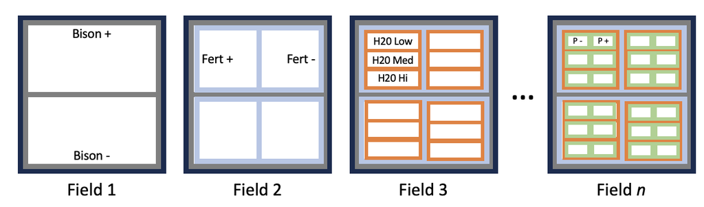

*Emphasize the **cow plots**, the **fertilizer plots**, the **water plots**, and the **pesticide** plots*

How many rows would our Excel file have for this design?

- 6 fields
- 2 bison treatments
- 2 fertilizer treatments
- 3 water treatments
- 2 pesticide treatments
- **Total:** 6 fields * 2 bison treatments * 2 fertilizer treatments * 3 water treatments * 2 pesticide treatments = **144 biomass measurements**

There would be 144 pesticide plots, and we would take a biomass measurement from each one. **144 total measurements = 144 rows in our Excel file.**

This is called a ‘split-plot design’! Lots of plot splitting happening here.

**Q:** We have 144 samples to look at the effect of pesticide. Do we have 144 samples to look at the effect of water? **The number of samples to test for the effect of water is the number of *water plots*!**

- We have $6 * 2 * 2 * 3 = 72$ water plots.
- We have 24 fertilizer plots.
- We have 12 bison plots.

This is important! While we have 144 rows, our sample sizes differ depending the effect we are testing for.

We could simplify the model and just test for an effect of bison, for example. But then we would introduce a lot of pseudoreplication into the design. We only have a sample size of 12 plots to test for the effect of bison. Therefore, to avoid that pseudoreplication, we have to account for these nested random effects in our model.

We may also want to look at the effect of these all at the same time, because we want to account for swamping.

A scary thing about this design is that the people who do these experiments are interested in interactions. Two-way interactions (e.g., bison, fertilizer; water, fertilizer; fertilizer, pesticides), three-way interactions (e.g., bison, water, pesticide), or four-way interactions…??

But the important part of this design is we need to account for pseudoreplication. We can do that using **random effects in our model**, and these random effects are **nested** according to the split-plot structure of our experiment. We need to specify to R: each fertilizer plot is nested within bison plots; each water plot is nested within fertilizer plots; and each pesticide plot is nested within water plots.

## Statistical model

$Biomass = \beta_0 + \beta_1Bison + \beta_2Fertilizer + \beta_{3,4}Water + \beta_5Pesticide + epsilon_{field} + epsilon_{field|bison} + epsilon_{field|bison|fertilizer} + epsilon_{field|bison|fertilizer|water} + epsilon_{residual}$

- between-field error (*variability among fields*)
- between-bison plot error (*variability within fields due to bison; i.e., residual error for the bison effect*)
- between-fertilizer plot error (*variability within bison treatments due to fertilizer; residual error for the fertilizer effect*)
- between-water plot error (*variability within fertilizer treatments due to water treatments; residual error for the water effect*)
- residual error

**Q:** Why is there no pesticide random effect? **No**, we can’t include it because each pesticide treatment is only measured once. Maybe if we had a repeated-measures through time for pesticides, then we could have a pesticide effect. But we don’t. Instead, the $\epsilon_{residual}$ is the error term for the pesticide effect.

**Q:** Are we double-counting fixed effects as random effects? **No.** The fixed-effect for bison is different from the field|bison random effect. The fixed effect compares all bison plots to all no-bison plots. The random effect is different because *bison is nested within field*, and every field has a different effect, so the bison effects are different within every different field.

- The fixed effect says: all bison plots have less biomass than non-bison plots.
- The nested random effect says: every field is different (field 1, 2, 3, …, 6), and every bison-plot within each of those fields is different from each other.
- Since the **fixed effect** variables are **nested** within **random effects**, we can treat them as both fixed and random effects.

Last thing: what if we wanted to test for **interactions**…?

Let’s say we added an interaction term, $\beta_6 * Bison * Fertilizer$. What is the meaning of $\beta_6$?

- When we add $\beta_6$, then $\beta_1$ becomes the effect of bison in unfertilized plots, $\beta_2$ becomes the effect of fertilizer in no-bison plots, and $beta_6$ becomes the difference in the effect of bison between fertilizer and no fertilizer plots.

Let’s say we added an interaction term, $\beta_7 * Fertilizer * Pesticide$. What is the meaning of $\beta_7$?

- When we add $\beta_7$, then $\beta_5$ becomes the effect of pesticide in unfertilized plots, $\beta_2$ becomes the effect of fertilizer in no-bison and no-pesticide plots, and $\beta_5 + \beta_7$ becomes the effect of pesticides in fertilized plots. So $\beta_7$ becomes the difference in the effect of pesticide between fertilizer and no fertilizer plots.

Let’s say we added another interaction term, $\beta_8 * Fertilizer * Pesticide * Bison$. What is the meaning of $\beta_8$…?!

- We’ve just changed the meaning of $\beta_6$…
- Before, $\beta_6$ was the difference between the effect of bison in fertilizer and unfertilized plots. Now that we have the interaction, $\beta_6$ is the difference in the effect of bison between fertilized and unfertilized plots *in no-pesticide plots*.
- Which means, $\beta_8$ is… the *difference in* the difference in the effect of bison between fertilizer and no fertilizer plots *between pesticide plots and no pesticide plots*.

Graphically, this might look like…

*Brian draw graphs on the board…*

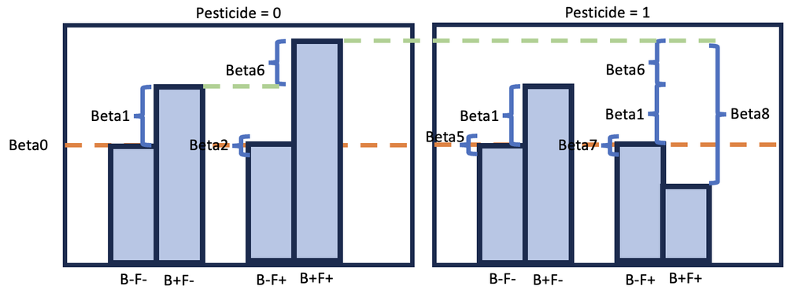

PESTICIDE = 0 PANEL

- B-F- = beta0
- B+F- = beta0 + beta1
- B-F+ = beta0 + beta2
- B+F+ = beta0 + beta1 + beta2 + beta6

PESTICIDE = 1 PANEL

- B-F- = beta0 + beta5
- B+F- = beta0 + beta1 + beta5 (no unique beta here b/c no interaction between bison and pesticide)
- B-F+ = beta0 + beta2 + beta5 + beta7
- B+F+ = beta0 + beta1 + beta2 + beta6 + beta5 + beta7 + beta8

**Take-home message:** this gets confusing really quickly… don’t do three-way interactions. It can be done, but it’s difficult to interpret.

## Split-plot analysis in R

Let’s examine how to analyze these data, without interactions, in R. Let’s take a look at a dataset:

```r
# Load the data
datum <- read.csv("lecture_19_dataset1.csv")

# Examine it
head(datum, 10)
```

```
##    Field Bison Fertilizer  Water WaterMed WaterHigh FieldError BisonError
## 1      1     0          0    Low        0         0 -0.5604756  0.9218324
## 2      1     0          0 Medium        1         0 -0.5604756  0.9218324
## 3      1     0          0   High        0         1 -0.5604756  0.9218324
## 4      1     0          1    Low        0         0 -0.5604756  0.9218324
## 5      1     0          1 Medium        1         0 -0.5604756  0.9218324
## 6      1     0          1   High        0         1 -0.5604756  0.9218324
## 7      1     1          0    Low        0         0 -0.5604756 -2.5301225
## 8      1     1          0 Medium        1         0 -0.5604756 -2.5301225
## 9      1     1          0   High        0         1 -0.5604756 -2.5301225
## 10     1     1          1    Low        0         0 -0.5604756 -2.5301225
##     FertError       Error  Biomass
## 1   1.4027118 -1.26539635 20.49867
## 2   1.4027118  2.16895597 33.93302
## 3   1.4027118  1.20796200 32.97203
## 4  -0.9455828 -1.12310858 28.29267
## 5  -0.9455828 -0.40288484 39.01289
## 6  -0.9455828 -0.46665535 38.94912
## 7  -2.1356474  0.77996512 25.55372
## 8  -2.1356474 -0.08336907 34.69039
## 9  -2.1356474  0.25331851 35.02707
## 10 -0.4359498 -0.02854676 36.44491
```

I simulated data with the split-plot design we explored on the board, but I didn’t go all the way out to the pesticide treatment because that was ridiculously complex.

Instead, there are 6 fields, that are split in half (bison, no bison), which are split in half (fertilizer, no fertilizer), which are split into thirds (low, medium, and high water).

We can dive into what the true values are for each effect, but I am not actually super worried about that. Instead, this is a pseudoreplication problem, and we want to make sure that we specify this model properly so that R gets the correct sample size for each effect…!

However, to start, let’s assume that we did not recognize the split-plot design of the model. Instead, we fit a simple ‘lme()’ with only a random-effect of field.

```r
# Linear-mixed effects model w/ random effect of field
library(nlme)
results <- lme(Biomass ~ Bison + Fertilizer + Water, data = datum, random = ~1|Field)
summary(results)
```

```
## Linear mixed-effects model fit by REML
##   Data: datum
##        AIC      BIC    logLik
##   340.9032 356.3361 -163.4516
##
## Random effects:
##  Formula: ~1 | Field
##         (Intercept) Residual
## StdDev:    2.741625 2.216146
##
## Fixed effects:  Biomass ~ Bison + Fertilizer + Water
##                 Value Std.Error DF    t-value p-value
## (Intercept) 31.039155 1.2624633 62  24.586184  0.0000
## Bison        8.725018 0.5223506 62  16.703374  0.0000
## Fertilizer   9.532282 0.5223506 62  18.248819  0.0000
## WaterLow    -9.673077 0.6397463 62 -15.120178  0.0000
## WaterMedium  0.152507 0.6397463 62   0.238387  0.8124
##  Correlation:
##             (Intr) Bison  Frtlzr WatrLw
## Bison       -0.207
## Fertilizer  -0.207  0.000
## WaterLow    -0.253  0.000  0.000
## WaterMedium -0.253  0.000  0.000  0.500
##
## Standardized Within-Group Residuals:
##        Min         Q1        Med         Q3        Max
## -1.7158786 -0.7221757  0.1008264  0.6731568  2.1067021
##
## Number of Observations: 72
## Number of Groups: 6
```

```r
# 72 observations with 6 groups (fields)... does not account for pseudoreplication properly, we need better nesting
```

The summary says we have 72 observations with 6 groups (fields). Take a look at the Degrees of Freedom (DF). We can go into the exact math of degrees of freedom, but it’s complicated and I don’t pretend to understand it entirely.

However, a good **rule of thumb** is that the DF has to be less than the number of samples that should be used. In this case, it is using at least 62 samples when estimating each of these effects. In fact, it’s using all 72 (‘72 observations’ at the bottom).

**Q:** How many samples do we have for ‘bison’? In truth, we actually have 12 bison plots: 6 with bison, and 6 without. So the true Degrees of Freedom for bison should be less than 12. But it says 62, which means we are pseudoreplicating with respect to bison, and also fertilizer as well. However, we have not pseudoreplicated with respect to ‘water’, as all 72 samples are used to test the effect of water. The water sample is the ‘ultimate sample’.

Part of the definition of a split-plot design is that *you have different sample sizes for different variables* ([link](https://www.stat.purdue.edu/~zhanghao/STAT514/Lecture_Notes/LectureNotes20-Split-plot-Designs-.html)). So we need to remove this pseudoreplication to correctly measure and test these effects.

```r
### Split-plot Design
# Linear-mixed effects model w/ random, nested effects
results2 <- lme(Biomass ~ Bison + Fertilizer + Water, data = datum, random = ~1|Field/Bison/Fertilizer)
summary(results2)
```

```
## Linear mixed-effects model fit by REML
##   Data: datum
##        AIC      BIC    logLik
##   283.9394 303.7817 -132.9697
##
## Random effects:
##  Formula: ~1 | Field
##         (Intercept)
## StdDev:    2.252141
##
##  Formula: ~1 | Bison %in% Field
##         (Intercept)
## StdDev:    2.083263
##
##  Formula: ~1 | Fertilizer %in% Bison %in% Field
##         (Intercept)  Residual
## StdDev:     1.55692 0.9667523
##
## Fixed effects:  Biomass ~ Bison + Fertilizer + Water
##                 Value Std.Error DF   t-value p-value
## (Intercept) 31.039155 1.3916143 46  22.30442  0.0000
## Bison        8.725018 1.3793418  5   6.32549  0.0015
## Fertilizer   9.532282 0.6752206 11  14.11729  0.0000
## WaterLow    -9.673077 0.2790774 46 -34.66092  0.0000
## WaterMedium  0.152507 0.2790774 46   0.54647  0.5874
##  Correlation:
##             (Intr) Bison  Frtlzr WatrLw
## Bison       -0.496
## Fertilizer  -0.243  0.000
## WaterLow    -0.100  0.000  0.000
## WaterMedium -0.100  0.000  0.000  0.500
##
## Standardized Within-Group Residuals:
##         Min          Q1         Med          Q3         Max
## -2.00392906 -0.60942998 -0.05624537  0.55973577  2.16707797
##
## Number of Observations: 72
## Number of Groups:
##                            Field                 Bison %in% Field
##                                6                               12
## Fertilizer %in% Bison %in% Field
##                               24
```

```r
# The random effects are nested with field > bison > fertilizer. Water is not included, because it is our 'ultimate sample' and therefore is the residual error. We only have one sample for each water plot, so we can't disentangle error due to water measurements being different from residual error.
```

Let’s take a look at the bottom of this. It says we have 72 observations (correct), 24 fertilizer plots (correct), 12 bison plots (correct), and 6 fields (correct)!

If we scroll up and look at the Degrees of Freedom, it’s using 46 for water, 11 for fertilizer, and 5 for bison. All of these are less than the number of groups from below, which is good. It is correctly measuring the amount of replication in our model; we are using the correct sample size for each of our particular variables.

We also get random effects for each variable. Reading them from the bottom upward:

- Residual error: error for the water treatment
- Intercept error: variation in biomass due to fertilizer treatment
- Bison %in% field: variation in biomass due to bison effect
- Field: variation in biomass due to field

**Questions?**

You may think this is crazy – but many of you may have more difficult designs than this!

This design is fully factorial, and balanced, and isn’t missing data due to field constraints, lazy technicians, or other weird problems that inevitably arise.

What happens if we add in ‘water’ as a final, nested random effect?

```r
# Linear-mixed effects model w/ random, nested effects
results3 <- lme(Biomass ~ Bison + Fertilizer + Water, data = datum, random = ~1|Field/Bison/Fertilizer/Water)
summary(results3)
```

```
## Linear mixed-effects model fit by REML
##   Data: datum
##        AIC      BIC    logLik
##   285.9394 307.9864 -132.9697
##
## Random effects:
##  Formula: ~1 | Field
##         (Intercept)
## StdDev:    2.252067
##
##  Formula: ~1 | Bison %in% Field
##         (Intercept)
## StdDev:    2.083249
##
##  Formula: ~1 | Fertilizer %in% Bison %in% Field
##         (Intercept)
## StdDev:     1.55694
##
##  Formula: ~1 | Water %in% Fertilizer %in% Bison %in% Field
##         (Intercept)  Residual
## StdDev:   0.7946576 0.5505715
##
## Fixed effects:  Biomass ~ Bison + Fertilizer + Water
##                 Value Std.Error DF   t-value p-value
## (Intercept) 31.039155 1.3915938 46  22.30475  0.0000
## Bison        8.725018 1.3793387  5   6.32551  0.0015
## Fertilizer   9.532282 0.6752284 11  14.11712  0.0000
## WaterLow    -9.673077 0.2790773 46 -34.66092  0.0000
## WaterMedium  0.152507 0.2790773 46   0.54647  0.5874
##  Correlation:
##             (Intr) Bison  Frtlzr WatrLw
## Bison       -0.496
## Fertilizer  -0.243  0.000
## WaterLow    -0.100  0.000  0.000
## WaterMedium -0.100  0.000  0.000  0.500
##
## Standardized Within-Group Residuals:
##         Min          Q1         Med          Q3         Max
## -1.14124834 -0.34707425 -0.03203222  0.31877351  1.23416705
##
## Number of Observations: 72
## Number of Groups:
##                                       Field
##                                           6
##                            Bison %in% Field
##                                          12
##            Fertilizer %in% Bison %in% Field
##                                          24
## Water %in% Fertilizer %in% Bison %in% Field
##                                          72
```

```r
# Water is included when it was not needed to be included.
```

For the most part, it gives us the exact same answer. R is smart enough to recognize that ‘water’ is the ‘ultimate sample’ and measures it as such: 72 samples for water in fert. in bison in field.

It doesn’t change any of our *t*-values or *p*-values.

It does do something weird, where it tries to partition the water error into error due to water treatment and some additional residual error. I don’t know how R tries to do this, but it does. But ultimately it doesn’t matter, because it is ultimately using the water-plot to look at the water-effect, with correct sample sizes, which is what we are after.

**Q1:** It is testing whether ‘high water’ is different from ‘low water’ and ‘medium water’. How do we test if ‘low water’ is different from ‘medium water’? **Re-level and re-run**

**Q2:** What if want to know if water ‘as a whole’ is significant? **F-drop test!** We run it again without water, and do an F-drop test to compare the two models. And remember, we have to change it to be a ‘maximum likelihood model’, rather than a REML model.

There is one last thing I want to mention about this model. Again, sometimes you all are going to have models more complicated than this! One of the reasons this model works is that R recognizes that all of the effects are linked to the plots that are nested within each other. But if you start having ‘missing data’ or other structural anomolies, it can be hard for R to recognize the design of your data and model. There are some other algorithms you can use:

```r
# Help file for lme()
help(lme)
# Notice the optimMethod -- an alternative optimization methods that allows you to change how it recognizes the correct degrees of freedom.
```

Notice the ‘optimMethod’ – an alternative optimization methods that helps the model recognize the correct degrees of freedom. Sometimes this can’t be fixed… but maybe it doesn’t matter. If your sample sizes are large (>100 for treatments), then it shouldn’t matter too much because the p-values converge at those larger sample sizes.

## Nested ANCOVA Design

Let’s do one more example, using a dataset we have seen before:

- $Y = size$
- $X_1 = age$
- $X_2 = sex$

This is an example that we are pretty comfortable with.

We have previously assumed that every one of our points came from a different individual. But now let’s say that every point came from the *same individual*. (We also looked at this with tree sizes, as another example.)

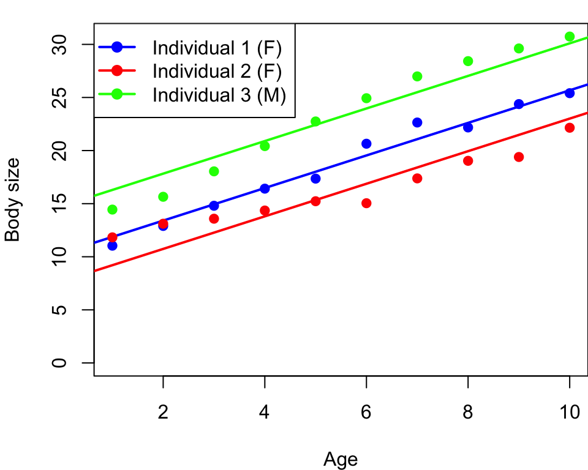

**Q:** What did we call this particular design, where we measured individuals repeatedly over time. **Repeated measures design**.

Technically, we need to worry about autocorrelation… but there is another thing we need to be worried about that we have not so far.

Our individuals differ in **sex**: female, female, male, female, etc.

- **10 individuals**
- **1-10 years old**
- **100 total points**

**Q1:** What do you think our sample size is for looking at the **effect of age** on body size?

- A lot of people might say ‘10’, because we only have ten individuals.
- **But it’s actually 100 samples for looking at the effect of age on size**.
- The reason is because: for every single point here, **the X-value changed for age**.
- These points may be *autocorrelated* with eachother… but since they changed, that makes those points *true replicates* for looking at the **effect of age on body size**.

**Q2:** Let’s take this to an extreme. Imagine we only had 1 individual, which we measured 10 times. **Can we test for the effect of age on size?**

- **Yes**, we can! Each observation is a true replicate for looking at the effect of age on size.
- However, this is **weak inference**, because it’s hard to make conclusions beyond that single individual.
- But, it’s technically not pseudoreplication. We have true replicates, but we have weak inference.

**Q3:** How many samples do we have to look at the effect of sex? **Ten**. The **sex of the individual cannot change**, which makes each one of those points a *pseudoreplicate* for looking at the effect of sex.

**Q4:** How many samples do we have to look at an *interaction* – a sex by age interaction? 10 or 100?

- A little more complicated… the answer is **100 samples**.
- Each sample is actually a true replicate for looking at the interaction between age and size, **because *age* did change**.
- **Rule of thumb**: when it comes to interactions, whatever variable has the greatest number of samples – this becomes the number of samples for your interactions.

Let’s learn how to run this analysis in R:

```r
### Nested ANCOVA Design
# Read the data
datum <- read.csv("lecture_19_dataset2.csv")

# Examine
head(datum, 15)
```

```
##    Individual Age Male   IndError      Error     Size
## 1           1   1    0 -1.6814269  1.2240818 11.04265
## 2           1   2    0 -1.6814269  1.5838956 12.90247
## 3           1   3    0 -1.6814269  1.9846671 14.80324
## 4           1   4    0 -1.6814269  2.0953498 16.41392
## 5           1   5    0 -1.6814269  1.5395087 17.35808
## 6           1   6    0 -1.6814269  3.3264218 20.64499
## 7           1   7    0 -1.6814269  3.8242723 22.64285
## 8           1   8    0 -1.6814269  1.8576551 22.17623
## 9           1   9    0 -1.6814269  2.5590110 24.37758
## 10          1  10    0 -1.6814269  2.0862196 25.40479
## 11          2   1    0 -0.6905325  1.0183959 11.82786
## 12          2   2    0 -0.6905325  0.8004210 13.10989
## 13          2   3    0 -0.6905325 -0.2255835 13.58388
## 14          2   4    0 -0.6905325 -0.9544747 14.35499
## 15          2   5    0 -0.6905325 -1.5795140 15.22995
```

Briefly looking at our data, we have 10 individuals that we have each measured 10 years, 5 females (0) and 5 males (1).

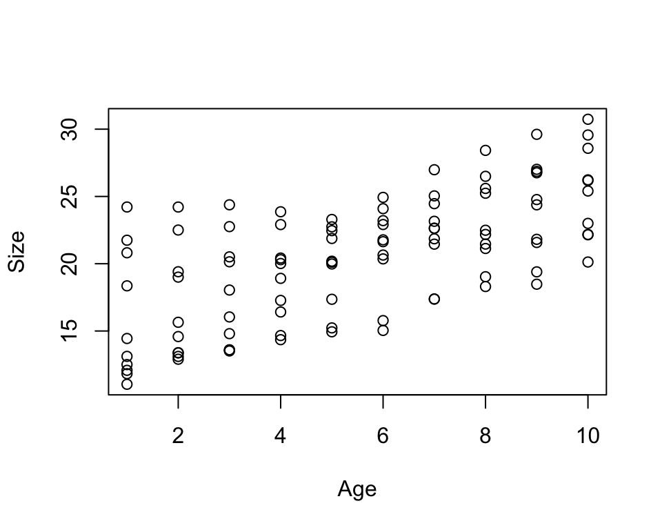

```r
# Plot it
plot(Size ~ Age, data = datum)
```

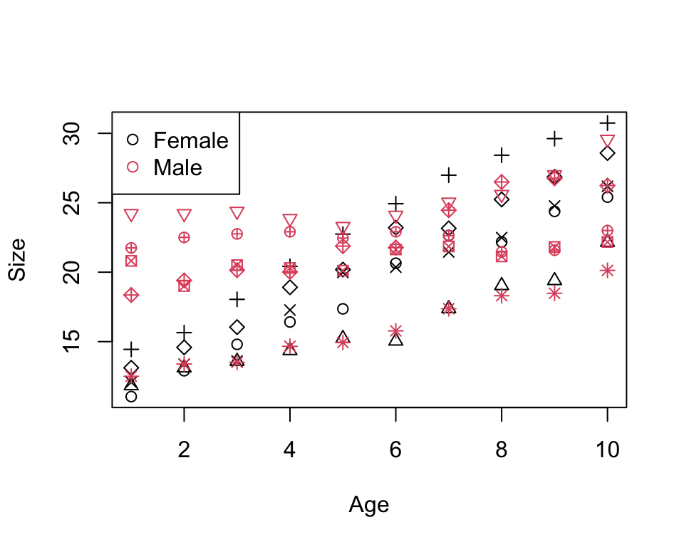

```r
# You can almost see that there are ten individuals here....

# Plot with points colored by sex and shaped by individual... a bit messy, but:
plot(Size ~ Age, data = datum, pch = as.numeric(datum$Individual), col = as.numeric(datum$Male) + 1)
legend("topleft", legend = c("Female", "Male"), pch = c(21, 21), col = c(1, 2))
```

I am not going to worry about autocorrelation, because you know how I feel about it: it ain’t worth it!

In terms of nesting structure here, INDIVIDUAL is NOT nested within AGE, because every INDIVIDUAL got every AGE. But individual is nested within SEX, because not every individual got every sex. The design expands from top-to-bottom with: Sex < Individual < Age.

*Brian draw nesting on board*

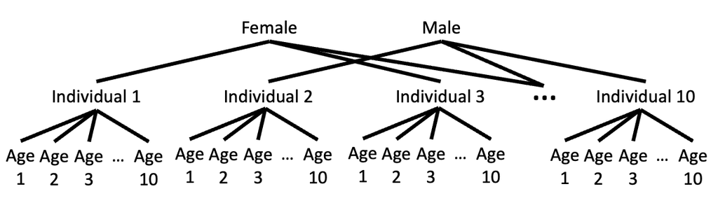

The hierarchy spreads *spread out* from the top down to the bottom for this nested design.

Age and sex our **fixed effects**, so we won’t list them as a random effect. All we will do is list ‘individual’ as random effect, and **R will automatically recognize that individual is nested within sex**. The key thing here is: by doing this, R will force individual to be our *sample* for looking at the effect of sex.

```r
# LME with Age and Sex fixed effects and random effect of individual (repeated measures!)
library(nlme)
results <- lme(Size ~ Age + Male, data = datum, random = ~1|Individual)
summary(results)
```

```
## Linear mixed-effects model fit by REML
##   Data: datum
##        AIC      BIC   logLik
##   466.0281 478.9016 -228.014
##
## Random effects:
##  Formula: ~1 | Individual
##         (Intercept) Residual
## StdDev:    2.980666 2.075091
##
## Fixed effects:  Size ~ Age + Male
##                 Value Std.Error DF   t-value p-value
## (Intercept) 13.871340 1.4215770 89  9.757713  0.0000
## Age          1.050008 0.0722454 89 14.533910  0.0000
## Male         1.737157 1.9302820  8  0.899950  0.3944
##  Correlation:
##      (Intr) Age
## Age  -0.280
## Male -0.679  0.000
##
## Standardized Within-Group Residuals:
##          Min           Q1          Med           Q3          Max
## -2.141546684 -0.607007246  0.005251469  0.644985556  2.208190883
##
## Number of Observations: 100
## Number of Groups: 10
```

We want to **check the degrees of freedom** to make sure it does this appropriately! We see that it uses the appropriate <10 degrees of freedom for MALE (because we have 10 individuals), and then it uses <100 degrees of freedom for the effect of age (because we have 100 measurements at different ages).

Now let’s add in the **interaction term**:

```r
# LME with Age, Sex, and Age*Sex fixed effects and random effect of individual (repeated measures!)
library(nlme)
results2 <- lme(Size ~ Age + Male + Age:Male, data = datum, random = ~1|Individual)
summary(results2)
```

```
## Linear mixed-effects model fit by REML
##   Data: datum
##        AIC      BIC    logLik
##   383.8527 399.2388 -185.9263
##
## Random effects:
##  Formula: ~1 | Individual
##         (Intercept) Residual
## StdDev:    3.025137 1.278742
##
## Fixed effects:  Size ~ Age + Male + Age:Male
##                 Value Std.Error DF    t-value p-value
## (Intercept) 10.908952 1.4081575 88   7.746969  0.0000
## Age          1.588624 0.0629609 88  25.231922  0.0000
## Male         7.661934 1.9914355  8   3.847443  0.0049
## Age:Male    -1.077232 0.0890401 88 -12.098274  0.0000
##  Correlation:
##          (Intr) Age    Male
## Age      -0.246
## Male     -0.707  0.174
## Age:Male  0.174 -0.707 -0.246
##
## Standardized Within-Group Residuals:
##        Min         Q1        Med         Q3        Max
## -2.0236806 -0.6634826 -0.0428658  0.6755786  2.1923466
##
## Number of Observations: 100
## Number of Groups: 10
```

DF for Age:Male = 88 – so it used all 100 samples to look at the interaction between age and sex.

## Final design

I want to briefly describe one final design that is used by many graduate students. Let’s consider these variables:

- $Y = Pain$
- $X_1 = Treatment (drug/placebo)$ – (some sort of treatment)
- $X_2 = Time$

We have worked with 20 individuals, given them the drug/placebo, and measured their pain through time: 0 hours, 2 hours, 4 hours, 8 hours.

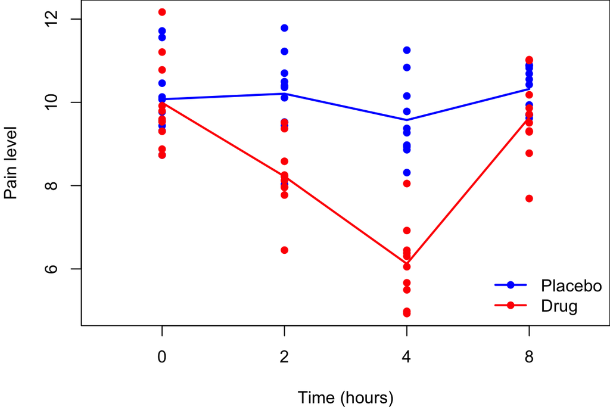

We assume that everyone’s pain is the same at the beginning. After 2 hours, the placebo individuals have the same pain, and drugged individuals have less pain. And this continues in this pattern through time… until it ultimately converges together again at 8 hours.

Let’s sketch out our **statistical linear model** for this study!

$Pain = \beta_0 + \beta_1Drug + \beta_{2-4}Time + \beta_{5-7}Drug*Time + epsilon_{ind} + \epsilon_{resid}$

We will treat the ‘**time**’ variable as **categorical**, because when we look at our data,, time does not have a **continuous** effect. We don’t want to assume a linear relationship between time and pain, so we treat time as categorical.

**Q:** Do we have an interaction? **Absolutely!** We actually don’t care about the individual effects of drug or time are… but what we really care about is the interaction effects through time. How does the **effect of drug *change* through time???**

Let’s think about the **sample sizes** for our **different effects**.

Every single point is a true replicate for looking at the effect of time AND every single point is a true replicate for looking at the **interaction between drug and time – which is our main interest**. We want to know *how these lines diverge.* How does the effect of drug *change* through time. The *difference* in the effect of drug in different time periods.

**Q:** If you get a significant interaction, what should you do? **Analyze things separately!** Start to analyze the different **time-chunks separately**.

*Brian draw blocks over the time steps on the graph*

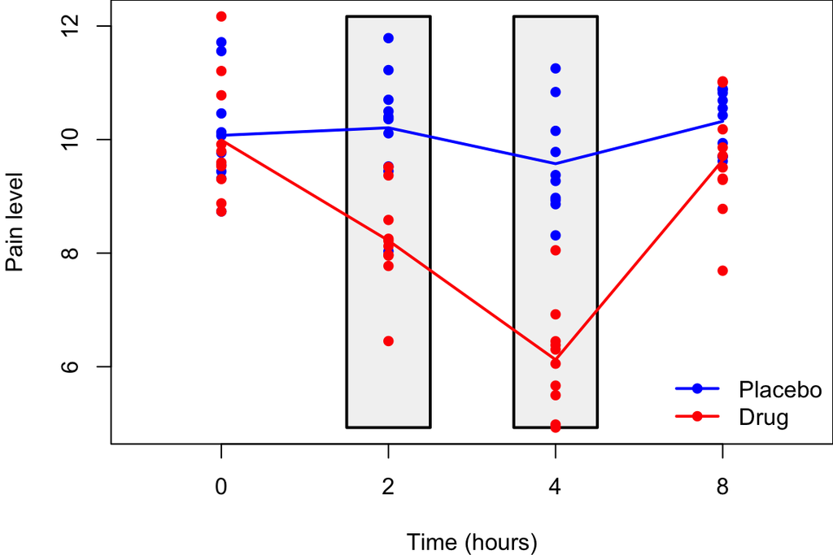

In each time-chunk, you model becomes:

$Pain = \beta_0 + \beta_1Drug$

In this case, **you won’t have to include random effects**, because you will only have 1 measurement for each individual in each time period, so pseudoreplication will not be an issue. You only need to include the random effect when you use the big, whole model.

So, **this model looks scary at first…!** But if you identify the significant interaction effect, then you can say: “We found a significant interaction between drug and time; therefore, we analyzed the **effect of drug separately *during each time period***.”

Many people often **jump straight into analyzing the effect of drug separately during each time period**, but **this is a mistake**.

- *Brian indicate that certain bars analyzed separately might be non-significant (NS)*
- Sometimes the noise will not produce significant differences at individual time steps.
- But the **global analysis with all the replicates** can identify the significant divergence due to the interaction effect.
- You can use the p-values from the full interaction model to provide support for groups being different within each time-step.

**Q:** Can anyone of you think of a common experimental design in natural sciences that would have the same statistical model as this described here? **Before-After Control-Impact (BACI) Design**

## Truth

Here is the code to create Truth for the two datasets analyzed here today.

```r
################### 'Truth' ####################
### Lecture 19: code to simulate data for class

### Dataset 1
# Simulate split-plot design data w/ three fixed effects: bison, fertilizer, water split across 6 fields
set.seed(123)

# Fields
n_fields <- 6
n_bison <- 2
n_fertilizer <- 2
n_water <- 3
Field <- sort(rep(rep(1:n_fields, n_bison*n_fertilizer*n_water)))

# Bison
Bison <- rep(sort(rep(c(0, 1), n_fertilizer*n_water)), n_fields)

# Fertilizer
Fertilizer <- rep(sort(rep(c(0, 1), n_water)), n_fields)

# Water
Water <- rep(c("Low", "Medium", "High"), n_fields * n_bison * n_fertilizer)
Water <- factor(Water, levels = c("Low", "Medium", "High"))
dummy <- data.frame(model.matrix(~ Water - 1))

# Field error
FieldError <- rep(rnorm(n_fields, 0, 1), each = n_bison * n_fertilizer * n_water)

# Bison error
BisonError <- rep(rnorm(n_bison * n_fields, 0, 2), each = n_fertilizer * n_water)

# Fertilizer error
FertilizerError <- rep(rnorm(n_fertilizer * n_bison * n_fields, 0, 2), each = n_water)

# Residual error
Error <- rnorm(length(Field), 0, 1)

# Response variable -- biomass
Biomass <- 20 + 10*Bison + 10*Fertilizer + 10*dummy$WaterMedium + 10*dummy$WaterHigh + FieldError + BisonError + FertilizerError + Error

# Save the data
datum <- data.frame(Field = Field, Bison = Bison, Fertilizer = Fertilizer, Water = Water, WaterMed = dummy$WaterMedium, WaterHigh = dummy$WaterHigh, FieldError = FieldError, BisonError = BisonError, FertError = FertilizerError, Error = Error, Biomass = Biomass)

# Save the data
write.csv(datum, "lecture_19_dataset1.csv", row.names = FALSE)


### Dataset 2
# Body size as a function of age and sex in multiple individuals
# Set the seed for reproducibility
set.seed(123)

# Individuals
n_individuals <- 10
n_samples <- 10
Individual <- sort(rep(1:n_individuals, n_samples))

# Sex
Male <- c(rep(rep(0, n_samples), n_individuals/2), rep(rep(1, n_samples), n_individuals/2))

# Age
Age <- rep(seq(1, n_samples, 1), n_individuals)

# Error due to individual
IndError <- rep(rnorm(n_individuals, 0, 3), each = n_samples)

# Error within individual (residual error)
# Simulate autocorrelated error - each value using the mean of the previous value
Error <- matrix(NA, length(Age), 1)
Error[1,1] <- rnorm(1, mean = 0, sd = 1)
for (i in 2:length(Age)){
  Error[i,1] <- rnorm(1, mean = Error[i-1, 1], sd = 1)
}

# Response variable - Size
Size <- 10 + 1.5*Age + 5*Male + -1*Male*Age + IndError + Error

# Save the data
datum <- data.frame(Individual = Individual, Age = Age, Male = Male, IndError = IndError, Error = Error, Size = Size)

# Save the data
write.csv(datum, "lecture_19_dataset2.csv", row.names = FALSE)
```

–go to next lecture–